# Notebook 03: Exploratory data analysis

# Goal:

In this notebook, I performed exploratory data analysis on the preprocess flow cytometry data and clinical data, which was imported using the readr package. First, I performed survival analysis and visualized the results by ploting Kaplan-Meier curve. Then, the global pattern of flow cytometry measurements in a sample was visualized using dimensional reduction and heatmap. Then, the markers was compared in fcs sample. The comparison of markers can also be plotted by pairwise scatter plots. Furthermore, the selected markers could visualized in one figure by merging multiple fcs data. The merged dataset can be further joined with the clinical data for more detailed exploration. Next, the distribution of markers measurements is compared using density plot. Finally, each cell was compared with each other and visualized via network plot. Most of the visualization are included to Shiny app in the forth notebook.

# Setup environment

import needed library

```r
library(tidyverse)
library(reshape2)
library(RColorBrewer) # library for general plotting
library(gridExtra)    # library for general plotting
library(survival)     # library for survival analysis
library(rms)          # library for survival analysis
library(flowCore)     # library for analyzing   flow dataset
library(flowStats)    # library for analyzing   flow dataset
library(flowViz)      # library for visualizing flow dataset
library(ggcyto)       # library for visualizing flow dataset
library(Rtsne)        # library for dimensional reduction (t-SNE)
library(pheatmap)     # library for plotting heatmap
library(networkD3)    # library for plotting network
```

setup required directory

```r
datadir <- "/data/Flow_HIV"
#####################################
load(file.path(datadir, "FlowHIV_Preprocessed_subset10.RData"))
fdats <- fs_trans_subset10
#load(file.path(datadir, "FlowHIV_Preprocessed_subset100.RData"))
#fdats <- fs_trans_subset100
#load(file.path(datadir, "FlowHIV_Preprocessed.RData"))
#fdats <- fs_trans
```

# Read in the clinical data of each patient

The clinical data contains the survival time and death of each patient.

```r
dat_clinic <- read_delim(
    file.path(datadir, "attachments", "clinical_data_flow_repository.csv"),
    delim = "\t")
colnames(dat_clinic)[2] <- "Surv_Time"
#dat_clinic <- dat_clinic %>% rename(Surv_Time = `Survival Time`)
dat_clinic$Surv_Obj <- with(dat_clinic, Surv(Surv_Time))
```

The data contains survival time and the patient IDs, which correspond to the file name of fcs files.

```r
head(dat_clinic)
```

| ID | Surv_Time | Death | Surv_Obj |
| --- | --- | --- | --- |
| 100715 | 63 | 0 | 63 |
| 105696 | 559 | 0 | 559 |
| 108701 | 1677 | 0 | 1677 |
| 109025 | 1937 | 0 | 1937 |
| 109567 | 1904 | 1 | 1904 |
| 110539 | 195 | 0 | 195 |

# Survival Analysis

Visualize the survival time in order

```
Ignoring unknown parameters: binwidth, bins, pad
```

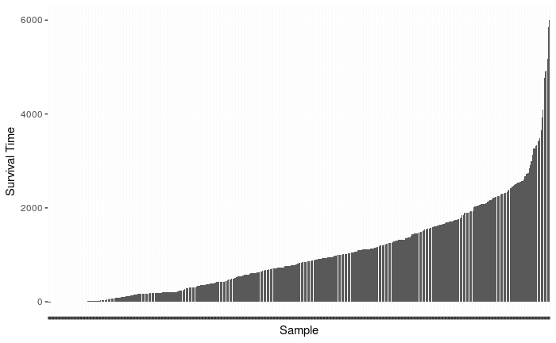

```r
dat <- dat_clinic
dat <- dat %>% arrange(Surv_Time)
dat$ID <- as.character(dat$ID)
dat$ID <- factor(dat$ID, levels = dat$ID)
ggplot(dat, aes(x = ID, y = Surv_Time)) +
    geom_histogram(stat = "identity") +
    xlab("Sample") +
    ylab("Survival Time") +
    theme(axis.text.x = element_blank())
```

```r
    #element_text(angle = 90, hjust = 1))
```

Fit the clinical data with survival model

```r
fit = npsurv(formula = Surv(Surv_Time) ~ 1, data = dat_clinic)
# The code below no longer work
# http://rstudio-pubs-static.s3.amazonaws.com/16003_8d6f2069af094998bfbb3d3a7dfb1c17.html
#fit <- survfit(
#    Surv_Obj ~ 1,
#    data = dat_clinic,
#    conf.type = "log-log")
#survplot(fit)
```

plot the Kaplan-meier curve

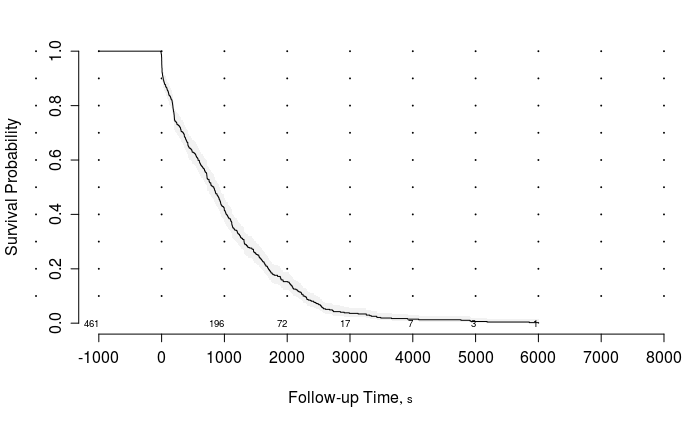

```r
survplot(
    fit,
    conf = c("none","bands","bars")[2],
    label.curves = TRUE,
    dots = TRUE,
    n.risk   = TRUE,
    time.inc = 1000)
```

# Dimension Reduction Visualization

Dimensional reduction plot allows researcher to visualize the distribution of high dimensional data at lower dimensional space. Here I used t-distributed stochastic neighbor embedding (t-SNE) to reduce the dimension of data. The advantage of t-SNE plot does not use linear transformation to preserved the distance of observation in high dimensional space. Therefore, it is better to visualize the complex pattern compared to other methods that applied linear transformation such as PCA, which applied eigendecomposition to decompose the covariance matris. Unlike PCA, the axes of t-SNE plot does not have obvious meaning, while in PCA, each axes represents a linear combination of variables.

```r
# set parameters
idx  <- 1
set_seed <- 0
num_events <- 1000
# select the target fcs sample
fdat <- fdats[[idx]]
expr <- exprs(fdat)
# randomly select rows
set.seed(set_seed)
idx_events <- sample(1:nrow(expr), num_events)
#
mat <- expr[idx_events, ] %>%
    as.tibble %>%
    dplyr::filter(`R780-A` > 0)
```

Perform t-SNE for dimensional reduction

```r
tsne_out = Rtsne(
    mat,
    dims = 2,
    perplexity = 30,
    theta = 0.5,
    max_iter = 1000)
```

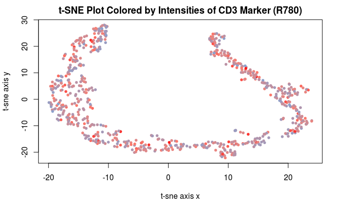

```r
# set color based on marker R780-A
rbPal      <- colorRampPalette(c(
    'red',      # red
    '#fb8072',  # rose
    '#8da0cb')) # blue
tmp_val    <- mat$`R780-A`
tmp_colors <- rbPal(20)[as.numeric(cut(tmp_val, breaks = 20))]
# plot the scatter plot
plot(
    tsne_out$Y, pch = 20,
    col  = tmp_colors,
    xlab = "t-sne axis x",
    ylab = "t-sne axis y",
    main = "t-SNE Plot Colored by Intensities of CD3 Marker (R780)")
```

# Using Heatmap to visualize the pattern of a preprocessed fcs data

Each intensity matrix belongs to [tidy data defined in R for data science](http://r4ds.had.co.nz/tidy-data.html), where each row represents a observation (cell) and each column is a variable (marker). For a sample, a certain fraction of cells were randomly selected for plotting. Here I plotted the first fcs file. In the shiny app, users can choose which file to plot.

```r
# set parameters for plotting
set_seed <- 0
fraction <- 0.05
idx      <- 1
# choose the targeted fcs file and get measurement values
fdat <- fdats[[idx]]
expr <- exprs(fdat)
# randomly select rows
set.seed(set_seed)
idx_events <- sample(
    1:nrow(expr),
    floor(fraction * nrow(expr)))
# set up column names
tmp1 <- fdat@parameters@data$name
tmp2 <- fdat@parameters@data$desc
len  <- length(tmp1)
col_name = c(
    tmp1[1:3],
    paste(tmp1[4:len], tmp2[4:len]))
colnames(expr) <- col_name
```

Set colors to better visualize the results.

```
the condition has length > 1 and only the first element will be usedthe condition has length > 1 and only the first element will be used
```

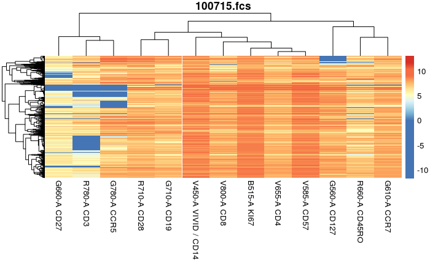

```r
# set up colors
tmp_colors <- rev(brewer.pal(9, "RdYlBu"))
tmp_colors <- c(
    rep(tmp_colors[1], each = 10),
    tmp_colors[2:7],
    rep(tmp_colors[8:9], each = 2))
color_pal <- colorRampPalette(tmp_colors)
# plot heatmap
pheatmap(
  mat               = expr[idx_events, 4:16],
  color             = color_pal(100),
  border_color      = NA,
  show_colnames     = TRUE,
  show_rownames     = FALSE,
  #annotation_col    = mat_col,
  #annotation_colors = mat_colors,
  clustering_distance_rows = "correlation",
  clustering_distance_cols = "correlation",
  drop_levels       = TRUE,
  fontsize          = 10,
  main              = sampleNames(fdats))
```

# Summary markers’ measurement values of one file

Here I plotted the first fcs file. In the shiny app, users can choose which file to plot.

```r
idx  <- 1
fdat <- fdats[[idx]]
```

plot pairwise scatter plot

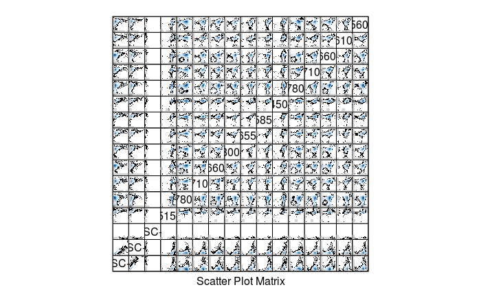

```r
print(splom(fdat))
```

summarise the distribution of each marker

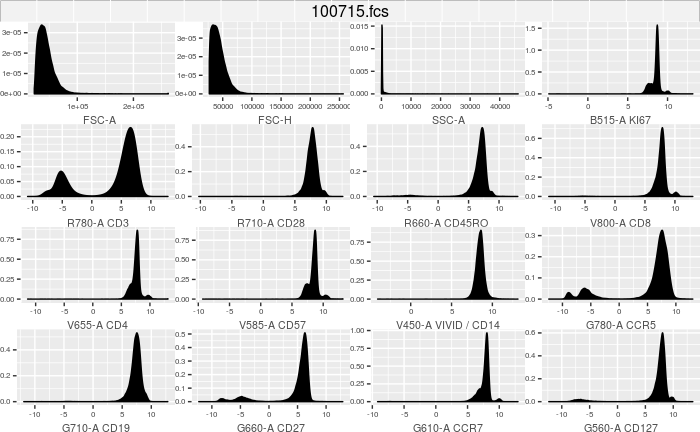

```r
autoplot(fdat)
```

# Comparing markers of different fcs files

[figure not shown]

```r
#plt <- xyplot(`FSC-A` ~ `R780-A`, fdats)
#print(plt)
densityplot(~ `V655-A`, fdats, main="Density plot of V655-A CD3")
```

The CD3 marker is a co-receptor specific to T-cells. CD3 is involved in T-cells activation, including cytotoxic T-cells (CD8+) and helper T-cells (CD4+). Therefore, the possible T-cells can be selected by selecting high intensity of the CD3 marker.

```r
# Gating Process:
# Choosing high intensity of CD3 marker
wf <- workFlow(fdats)
lg <- lymphGate(
    fdats,
    channels=c("FSC-A", "R780-A"),
    filterId="TCells", eval=FALSE,
    scale=2.5)
add(wf, lg$n2gate)
```

Visualize the gating results. The candidate cells were selected by red circle

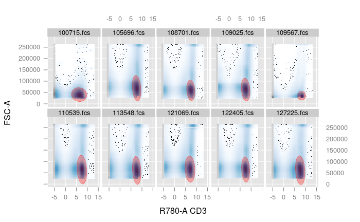

```r
plt <- xyplot(
    # specify data and markers
    `FSC-A` ~ `R780-A`, wf[["TCells+"]],
    # plot transparent red circle
    par.settings=list(gate=list(col="red", fill="red", alpha=0.3)))
print(plt)
```

Markers can be visualized by scatter plot in multiple fcs files. In the shiny app, both markers can be selected by users. As discussed in notebook 02, it is normal to observe some data points where markers have measurements smaller than zero. Most of the cells (> 60%) are at the first quadrant.

```r
# show #cells with both markers larger than zero
for (idx in 1:length(fdats)){
    tmp1 <- fdats[[idx]] %>% exprs %>% as.tibble %>%
        dplyr::filter(`R780-A` > 0, `R660-A` > 0) %>% nrow
    tmp2 <- fdats[[idx]] %>% exprs %>% as.tibble %>% nrow
    cat(sampleNames(fdats)[idx], ": Proportion of cells in 1st quadrant", tmp1 / tmp2, "\n")
}
```

```
100715.fcs : Proportion of cells in 1st quadrant 0.7304202
105696.fcs : Proportion of cells in 1st quadrant 0.7014153
108701.fcs : Proportion of cells in 1st quadrant 0.698159
109025.fcs : Proportion of cells in 1st quadrant 0.6206503
109567.fcs : Proportion of cells in 1st quadrant 0.7710434
110539.fcs : Proportion of cells in 1st quadrant 0.623041
113548.fcs : Proportion of cells in 1st quadrant 0.7732267
121069.fcs : Proportion of cells in 1st quadrant 0.6504208
122405.fcs : Proportion of cells in 1st quadrant 0.7680131
127225.fcs : Proportion of cells in 1st quadrant 0.7307534
```

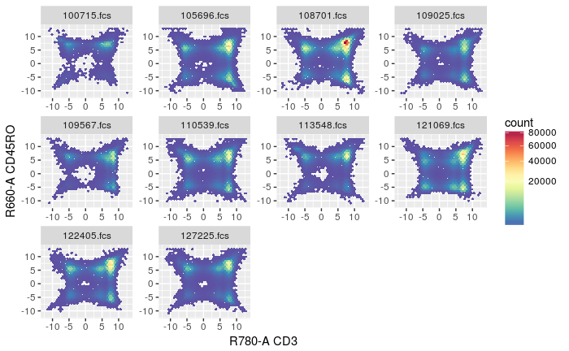

```r
# plot scatter plots
autoplot(fdats, "R780-A", "R660-A")
```

Merge the data to plot them in one figure. The clinical information is added into the plot to provide detailed exploration than the plot above. Note that to simplified the plot, only the 50% of the cell proportion in 1st quadrant was visualized in each sample.

```r
# initialization
res <- list() # container to store the intensity matrix of each sample
set_seed <- 0 # seed for randomization
# get the marker intensities of each sample
set.seed(set_seed)
for (idx in 1:length(fdats)){
    # expression matrix
    tmp = exprs(fdats[[idx]]) %>%
        as.tibble %>%
        dplyr::select(`R780-A`, `R660-A`) %>%
        dplyr::filter(`R780-A` > 0, `R660-A` > 0) %>%
        dplyr::rename(CD3 = `R780-A`, CD45RO = `R660-A`) %>%
        dplyr::sample_frac(0.5)

    # specify ID (file name)
    id <- str_split(
        sampleNames(fdats)[idx],
        "\\.",
        simplify = TRUE)[1, 1]
    tmp$ID <- as.numeric(id)

    # store the result
    res[[idx]] <- tmp
} # end for loop
# combine the results and joined with clinical data
res <- do.call(rbind, res)
res <- dplyr::left_join(res, dat_clinic, by = "ID")
res$ID <- as.character(res$ID)
```

Below I would plot the data points with color by ID and Survival Time. Both color scale were sorted by Survival Time.

```r
tmp <- res %>%
    arrange(Surv_Time) %>%
    dplyr::select(ID, Surv_Time) %>%
    distinct()
tmp
```

| ID | Surv_Time |
| --- | --- |
| 100715 | 63 |
| 110539 | 195 |
| 127225 | 223 |
| 121069 | 243 |
| 122405 | 550 |
| 105696 | 559 |
| 113548 | 1113 |
| 108701 | 1677 |
| 109567 | 1904 |
| 109025 | 1937 |

Set colors and plot scatter plot colored by survival time and ID. The marker CD45RO is expressed in T cells that have been exposed to antigen. That is, CD45RO can be used to distinguish the memory T cells from naive T cells.

```r
############################################
##### setup color for Survival Time #####
# color palatte
tmp_colors <- rev(brewer.pal(5, "Reds"))
color_pal  <- colorRampPalette(tmp_colors)
############################################
##### setup color for ID #####
# color palatte
tmp_colors <- rev(brewer.pal(10, "Blues"))
```

```
n too large, allowed maximum for palette Blues is 9
Returning the palette you asked for with that many colors
```

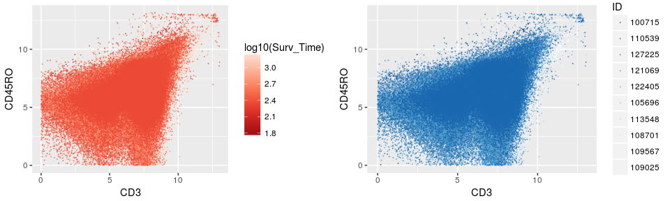

```r
fill_pal  <- colorRampPalette(tmp_colors)
# manual mapping ID & color
tmp <- res %>% arrange(Surv_Time) %>% dplyr::select(ID, Surv_Time) %>% distinct()
tmp_colors <- fill_pal(10)
names(tmp_colors) <- tmp$ID
# set ID factor
res$ID <- factor(res$ID, levels = tmp$ID)
############################################
##### Plot the scatter plots #####
# color by log10 survival time
gp1 <- ggplot(res, aes(x = CD3, y = CD45RO, color = log10(Surv_Time))) +
    geom_point(size = 0.1, alpha = 0.5) +
    scale_color_gradientn(colours = color_pal(10))
# color by ID
gp2 <- ggplot(res, aes(x = CD3, y = CD45RO, color = ID)) +
    geom_point(size = 0.1, alpha = 0.5) +
    scale_color_manual(values = tmp_colors)
# arrange two plots into one
grid.arrange(gp1, gp2, nrow = 1)
```

# Construct sample network

In the heatmap and scatter plot, it may not be easy to visualize the relationship among cells / observations. In this section, I used a different perspective to explore a cell population. For a sample, I first compared the cells (observations; rows) using correlation as distance function. The distance matrix was then converted to simiality matrix and further converted into adjacency matrix of a network by selecting an arbitrary cutoff value (which can be specify easily in the shiny app).

Note that I plotted one fcs file in this section. In the shiny app, users are allowed to choose any fcs file / sample.

```r
# intialization
idx  <- 1
num_events <- 1000
# plot the targeted fcs file
fdat <- fdats[[idx]]
expr <- exprs(fdat)
# randomly select rows
set.seed(set_seed)
idx_events <- sample(1:nrow(expr), num_events)
expr <- expr[idx_events, ]
# calculate the correlation distance
# (euclidean distance after standardization)
expr <- apply(expr, 2, scale)
mat_dist <- dist(expr[, 4:16]) # here I did not use the FSC and SSC for distance calculation
# convert the distance matrix into similarity matrix
mat_sim  <- 1 / (as.matrix(mat_dist) + 1)
diag(mat_sim) <- 0
```

Select edges with correlation larger than a specific value (ex: 0.5)

```r
cutoff <- 0.6
mat_adj   <- ifelse(mat_sim > cutoff, 1, 0)
links <- melt(mat_adj) %>% dplyr::filter(value == 1)
```

Visualize the network. Each node represents an observation / cell and the cluster of cells could be easily visualized in the network. Note that by setting zoom as TRUE, the network can be moved around and zoomed in/out using the computer mouse.

```r
simpleNetwork(links,
            fontSize     =  20,
            charge       = -10,
            linkDistance = 10,
            zoom = TRUE)
```

[interactive chart not shown]